# Week1_Homework_BST209

2025-07-30

## R Markdown

**Methods**

*Data pre-processing*: We obtained two NHANES datasets: covariates_df (9,813 participants, 860 variables) and the questionnaire file (10,175 participants, 953 variables). Using the unique identifier SEQN, we found 9,813 common IDs, merged the files on this key, and limited our analysis to participants with complete covariate data.

*Cancer outcome*: Our primary outcome was self-reported cancer diagnosis, captured by MCQ220 (“Have you ever been told by a doctor or other health professional that you had cancer or a malignancy of any kind?”). MCQ220 was answered by 5,588 of the 9,813 participants; we excluded the remainder (unknown status), which also removed 92 variables per participant.

*Missing data*: First, we removed all columns (variables) with more than 1000 missing values, which reduced the dataset to 368 variables. We then applied complete.cases() to the 5,588 remaining participants, dropping any participants with missing values, which reduced the dataset to 2,629 participants.

Table 1 shows baseline demographic characteristics of the cancer and non-cancer groups by age, gender, race/ethnicity, education level, marital status, household size, and income to poverty ratio. The distribution of variables in each group does not appear balanced, as the cancer group appears to have older mean age (54.9 +/- 11.7) a higher proportion of women (60.6%), higher education level (68.8% with at least some college), a higher percentage of married individuals (64.1%), and smaller household size (56.5% with 2 or fewer household members).

The first figure below shows a summary of counts in the non-cancer (2459 individuals) vs cancer groups (170 individuals). The second figure is a violin plot showing age distribution by cancer status. The 3rd figure similarly shows a density plot of age distribution by cancer status. As seen in these plots, the cancer group is distributed such that individuals appear to be distrubed at older ages than the non-cancer group with a more even distribution across younger and older ages.

The 4th figure shows a summary of gender distribution by cancer status. The cancer group features a higher proportion of women, while the non-cancer group features a relatively more even distribution between men and women.

The 5th figure shows a boxplot of age by gender and cancer status. The non-cancer group shows a fairly similar distribution of age and gender. The men in the cancer group feature older mean age than the women in the cancer group with a younger age distribution.

Table 1: Demographic Characteristics by Cancer Status

|  | No (N=2459) | Yes (N=170) | Total (N=2629) |
| --- | --- | --- | --- |
| Age (years) |  |  |  |
| Mean (SD) | 43.3 (14.0) | 54.9 (11.7) | 44.0 (14.2) |
| Median [Min, Max] | 43.0 [20.0, 69.0] | 57.5 [24.0, 69.0] | 44.0 [20.0, 69.0] |
| Gender |  |  |  |
| Male | 1270 (51.6%) | 67 (39.4%) | 1337 (50.9%) |
| Female | 1189 (48.4%) | 103 (60.6%) | 1292 (49.1%) |
| Race/Ethnicity |  |  |  |
| 1 | 322 (13.1%) | 15 (8.8%) | 337 (12.8%) |
| 2 | 231 (9.4%) | 13 (7.6%) | 244 (9.3%) |
| 3 | 1066 (43.4%) | 111 (65.3%) | 1177 (44.8%) |
| 4 | 491 (20.0%) | 24 (14.1%) | 515 (19.6%) |
| 5 | 349 (14.2%) | 7 (4.1%) | 356 (13.5%) |
| Education Level |  |  |  |
| 1 | 119 (4.8%) | 10 (5.9%) | 129 (4.9%) |
| 2 | 297 (12.1%) | 13 (7.6%) | 310 (11.8%) |
| 3 | 545 (22.2%) | 30 (17.6%) | 575 (21.9%) |
| 4 | 809 (32.9%) | 68 (40.0%) | 877 (33.4%) |
| 5 | 688 (28.0%) | 49 (28.8%) | 737 (28.0%) |
| 9 | 1 (0.0%) | 0 (0%) | 1 (0.0%) |
| Marital Status |  |  |  |
| 1 | 1287 (52.3%) | 109 (64.1%) | 1396 (53.1%) |
| 2 | 61 (2.5%) | 9 (5.3%) | 70 (2.7%) |
| 3 | 290 (11.8%) | 27 (15.9%) | 317 (12.1%) |
| 4 | 81 (3.3%) | 7 (4.1%) | 88 (3.3%) |
| 5 | 541 (22.0%) | 12 (7.1%) | 553 (21.0%) |
| 6 | 199 (8.1%) | 6 (3.5%) | 205 (7.8%) |
| Household Size |  |  |  |
| 1 | 292 (11.9%) | 24 (14.1%) | 316 (12.0%) |
| 2 | 605 (24.6%) | 72 (42.4%) | 677 (25.8%) |
| 3 | 505 (20.5%) | 29 (17.1%) | 534 (20.3%) |
| 4 | 447 (18.2%) | 23 (13.5%) | 470 (17.9%) |
| 5 | 313 (12.7%) | 8 (4.7%) | 321 (12.2%) |
| 6 | 143 (5.8%) | 12 (7.1%) | 155 (5.9%) |
| 7 | 154 (6.3%) | 2 (1.2%) | 156 (5.9%) |
| Income to Poverty |  |  |  |
| Mean (SD) | 2.63 (1.67) | 2.92 (1.71) | 2.64 (1.67) |
| Median [Min, Max] | 2.29 [0, 5.00] | 2.70 [0.0400, 5.00] | 2.31 [0, 5.00] |

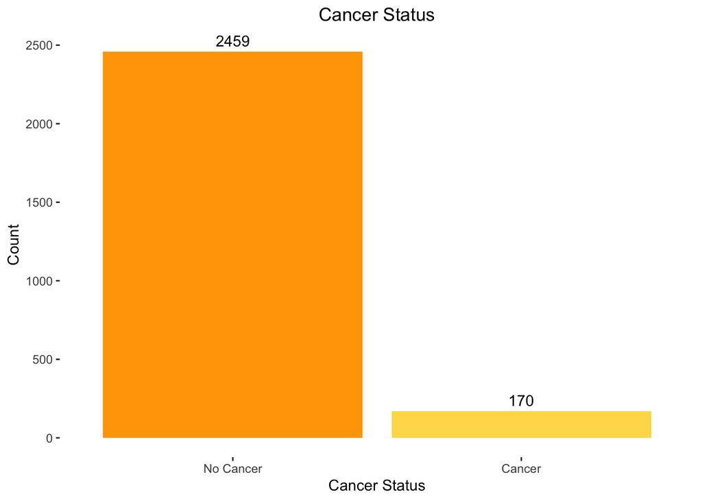

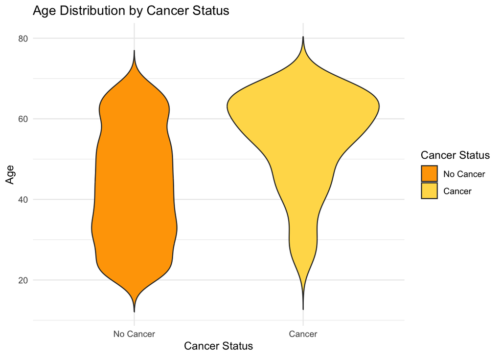

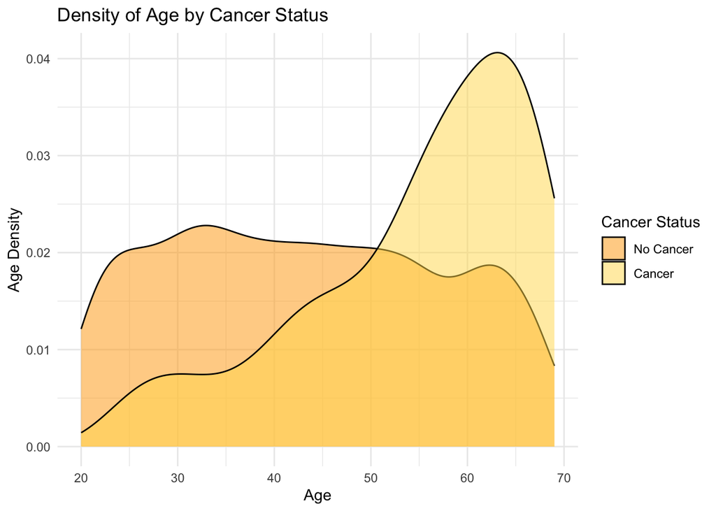

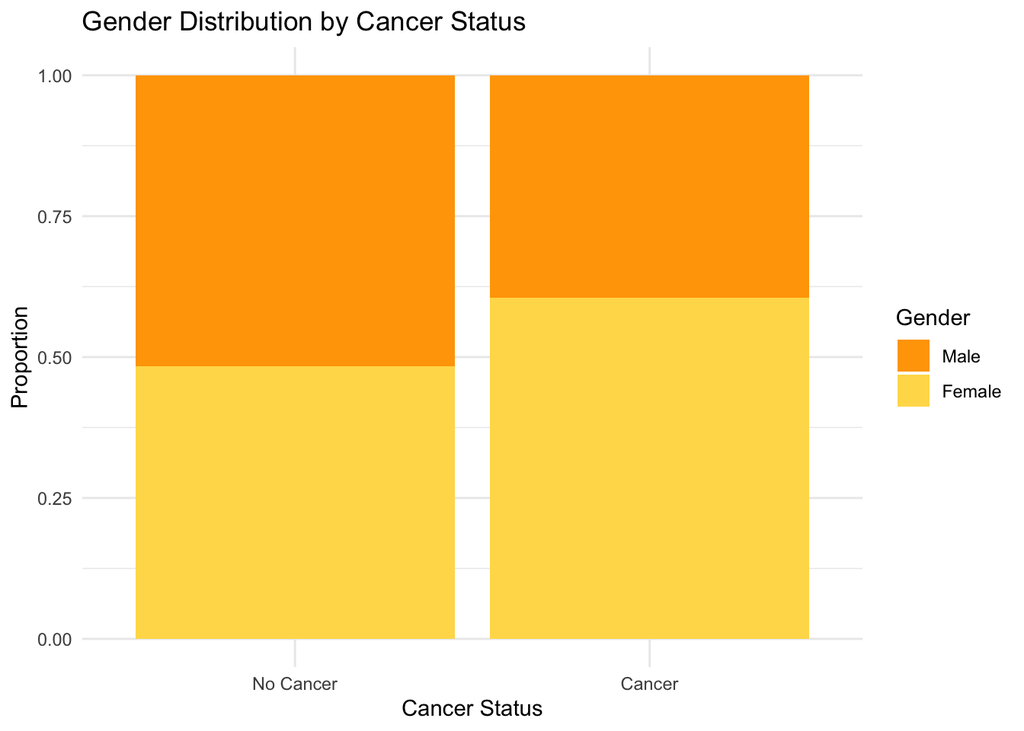

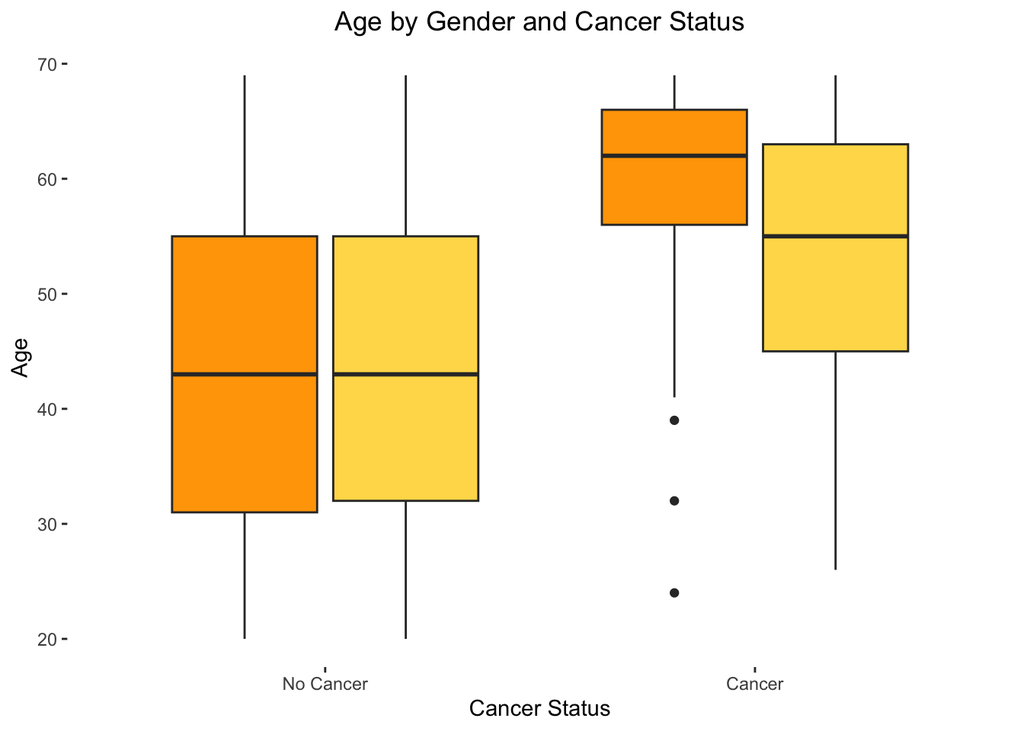

#End